# Introduction to Quarto

Reproducible documents for analytical work  
Adapted from https://r4ds.hadley.nz/quarto.html

Steve Rozen

2026-08-03

## Why Quarto and Markdown?

- **Communicate results, methods, and code in one reproducible document**
- **Reproducible.** Re-render the document and every number, figure, and table is recomputed from the data.
- **Multi-format.** The same `.qmd` source renders to HTML, dynamic dashboards, PDF, Word, slides (and websites and books).
- **Plain text.** Diffs cleanly in git, easy to review, easy to share.

## Why this matters for analysis

- No more “copy the number from the R console into the Word doc.”
- No more “which version of the figure did I paste into the slide?”
- Reviewers and collaborators can rerun the analysis end-to-end.
- Future-you, six months from now, can rerun it too.

## Use cases

- Communicate to decision-makers, who want to focus on the conclusions, not the code behind the analysis.
- Collaborate with other data scientists (including future you!), who are interested in both your conclusions, and how you reached them (i.e. the code).
- Use Quarto as a modern-day analysis notebook where you capture not only what you did, but also what you were thinking.

## What is a Quarto document?

A `.qmd` “Quarto markdown” file is a plain-text file with three kinds of content:

1. **YAML header** (metadata and output options).
2. **Markdown text** (prose, headings, lists, links).
3. **Code chunks** (executable R, Python, Julia, etc.).

You “render it” with `quarto render file.qmd` (or the Render button in RStudio / VS Code / Positron)

“Render” means execute the code and do the formatting to a final output format (e.g. HTML, dashboard, PDF, etc.) FYI, I wrote these slide in Quarto.

## 1. The YAML header

```yaml
---
title: "Diamond sizes"
author: "Hadley Wickham"
date: 2026-06-29
format: html
---
```

- Lives at the top, between `---` lines.
- Controls title, author, output format, and execution options.
- `format:` can be `html`, `pdf`, `docx`, `revealjs` (html slides), `dashboard` (html dashboard), …

## 2.1 Markdown text examples

```markdown
## Heading 2 (Most quarto docs use this the major section heading)

*italic*, **bold**, `code`, [a link](https://quarto.org)

- bullet
- list

1. numbered
2. list

| tiny | table |
-------|-------|
|  a   |   b   |
```

Lightweight conventions; render to any output format; easy to read as plain text.

*italic*, **bold**, `code`, [a link](https://quarto.org)

- bullet
- list
1. numbered
2. list

| tiny | table |
| --- | --- |
| a | b |

## 3. Code chunks

````markdown
```{r}
#| label: simple-addition

1 + 1
2 + 2
```
````

- Fenced with triple backticks and the engine name in braces (`{r}`).
- Options go after `#|` at the top of the chunk.
- Output (text, tables, figures) is inserted into the rendered document; simple-addition:

```
[1] 2
```

```
[1] 4
```

## Common chunk options

| Option | Effect |
| --- | --- |
| `echo` | Show the source code? |
| `eval` | Run the code? |
| `include` | Include code *and* output? (`false` hides both) |
| `message` | Show messages? |
| `warning` | Show warnings? |
| `error` | Keep rendering on error? (`true` to continue) |
| `results` | `"hide"` to suppress text output |
| `fig-show` | `"hide"` to suppress figures |

Set globally in YAML under `execute:` or per-chunk with `#|`.

## Exercises, Quarto basics

Markdown: https://quarto.org/docs/authoring/markdown-basics.html

Other cheatsheets: https://rstudio.github.io/cheatsheets/quarto.pdf

https://res.cloudinary.com/dyd911kmh/image/upload/v1676540721/Marketing/Blog/Quarto_Cheat_Sheet.pdf

1. Create a new Quarto document (File > New File > Quarto Document in RStudio). Read the instructions. Practice running the chunks individually. Render the document using the button and the keyboard shortcut. Modify the code, re-run, and verify the output changes.
2. Create one new Quarto document for each of the three built-in formats: HTML, PDF, and Word. Render each. How do the outputs differ? How do the inputs differ? (You may need to install LaTeX for PDF, RStudio will prompt you.)

## Exercises, source editor

1. Create a brief CV. Title is your name. Include headings for education and employment. Each section has a bulleted list of jobs / degrees. Put the year in **bold**.
2. Copy `diamond-sizes.qmd` from https://github.com/hadley/r4ds/tree/main/quarto into a local Quarto document. Run it, then add text after the frequency polygon describing its most striking features.

## Figures

Control figure size and captions with chunk options:

```r
#| label: fig-carat
#| fig-cap: "Diamond price vs carat."
#| fig-width: 6
#| fig-height: 4
#| out-width: "80%"
ggplot(diamonds, aes(carat, price)) + geom_hex()
```

- Label starting with `fig-` makes the chunk cross-referenceable.
- Reference it in prose as `@fig-carat`.

## Figure output

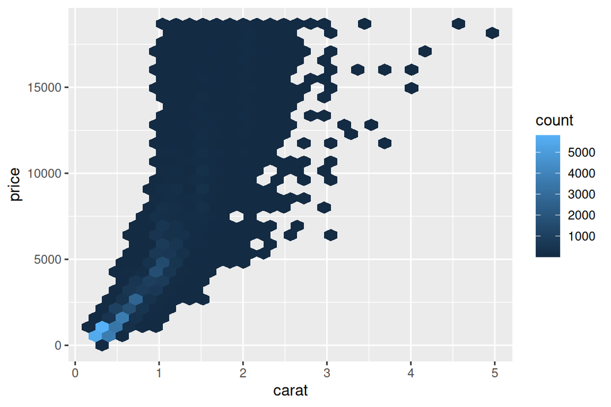

Figure 1: Diamond price vs carat.

## More on figures

Sizing figures and the text in figures in Quarto is tricky, because of mutliple frames of reference. On the next slide is the output of

````markdown
```{r}
library(tidyplots)
tidyplot(diamonds, carat, price) |>
    add(geom_hex(aes(fill = after_stat(count)), bins = 40)) |>
    add(scale_fill_viridis_c())
```
````

## Output from previous slide

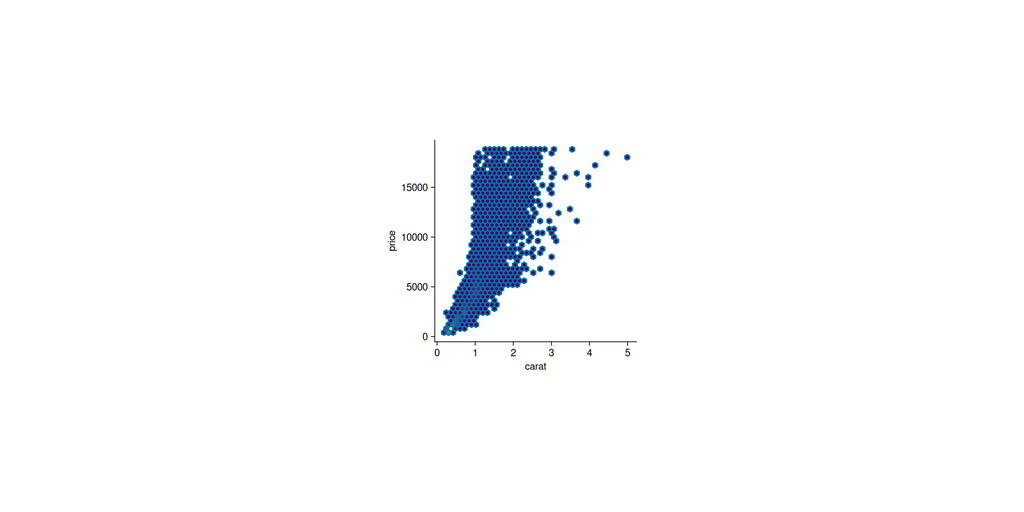

Figure 2

(`tidyplots` uses fixed output size by default)

## Try again

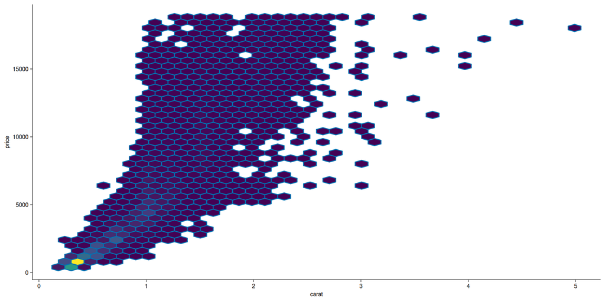

````markdown
```{r}
tidyplot(diamonds, carat, price, height = NA, width = NA) |>
    add(geom_hex(aes(fill = after_stat(count)), bins = 40)) |>
    add(scale_fill_viridis_c())
```
````

## Try again again

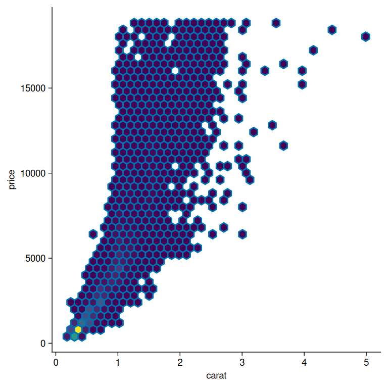

````markdown
```{r}
tidyplot(diamonds, carat, price, height = NA, width = NA) |>
    add(geom_hex(aes(fill = after_stat(count)), bins = 40)) |>
    add(scale_fill_viridis_c())
```
````

## Try yet again

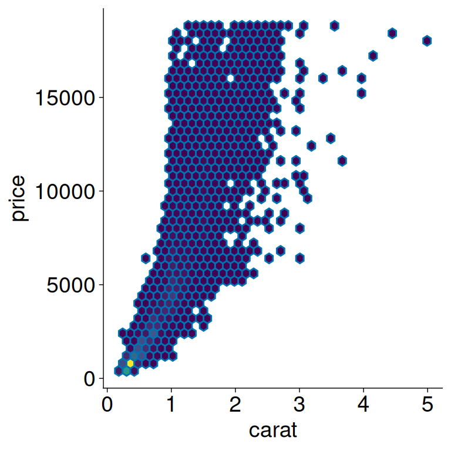

````markdown
```{r}
tidyplot(diamonds, carat, price, height = NA, width = NA) |>
    add(geom_hex(aes(fill = after_stat(count)), bins = 40)) |>
    add(scale_fill_viridis_c()) |>
    adjust_font(fontsize = 14)
```
````

## Coding agents have problems with figures in Quarto

Often get figure sizes and placement wrong at first

Guide to work arounds: can it be codified as an agent skill: https://github.com/steverozen/quarto-bioinfo

Beware of different ways to specify font sizes in different parts of `ggplot2` and different interactions with scaling in the output.

https://tidyverse.org/blog/2020/08/taking-control-of-plot-scaling/

## Figures — wait, there’s more

```r
#| label: fig-carat-ggplotly
#| fig-cap: "Diamond price vs carat."
#| fig-width: 6
#| fig-height: 4
#| out-width: "80%"
p <- ggplot(diamonds, aes(carat, price)) +
  geom_hex()
plotly::ggplotly(p)
```

[interactive chart not shown]

Figure 3: Diamond price vs carat.

## Figures – a more interesting ggplotly example

[interactive chart not shown]

Figure 4

## Figures – code for previous slide

The key is the argument `frame = year` in the call to `geom_point`

```r
data(gapminder, package = "gapminder")
gg <- ggplot(gapminder, aes(gdpPercap, lifeExp, color = continent)) +
  geom_point(aes(size = pop, frame = year, ids = country)) +
  scale_x_log10()
plotly::ggplotly(gg)
```

You can also call `plotly` directly. There’s a whole book by Carson Sieviert: https://plotly-r.com/

## Tables

````markdown
```{r}
#| label: tbl-diamonds
#| tbl-cap: "First five diamonds."
knitr::kable(head(diamonds, 5))
```
````

- Label starting with `tbl-` makes it a cross-referenceable table. - Reference in prose as `@tbl-diamonds`. - For richer tables: `gt::gt()`, `DT::datatable()`, `kableExtra`.

## Table output

Table 1: First five diamonds.

| carat | cut | color | clarity | depth | table | price | x | y | z |
| --- | --- | --- | --- | --- | --- | --- | --- | --- | --- |
| 0.23 | Ideal | E | SI2 | 61.5 | 55 | 326 | 3.95 | 3.98 | 2.43 |
| 0.21 | Premium | E | SI1 | 59.8 | 61 | 326 | 3.89 | 3.84 | 2.31 |
| 0.23 | Good | E | VS1 | 56.9 | 65 | 327 | 4.05 | 4.07 | 2.31 |
| 0.29 | Premium | I | VS2 | 62.4 | 58 | 334 | 4.20 | 4.23 | 2.63 |
| 0.31 | Good | J | SI2 | 63.3 | 58 | 335 | 4.34 | 4.35 | 2.75 |

## The `DT` package for interactive tables

Sort by any column, search, page through rows, all client-side in the rendered HTML.

Table 2

| carat | cut | color | clarity | depth | table | price | x | y | z |
| --- | --- | --- | --- | --- | --- | --- | --- | --- | --- |
| 0.23 | Ideal | E | SI2 | 61.5 | 55 | 326 | 3.95 | 3.98 | 2.43 |
| 0.21 | Premium | E | SI1 | 59.8 | 61 | 326 | 3.89 | 3.84 | 2.31 |
| 0.23 | Good | E | VS1 | 56.9 | 65 | 327 | 4.05 | 4.07 | 2.31 |
| 0.29 | Premium | I | VS2 | 62.4 | 58 | 334 | 4.2 | 4.23 | 2.63 |
| 0.31 | Good | J | SI2 | 63.3 | 58 | 335 | 4.34 | 4.35 | 2.75 |
| 0.24 | Very Good | J | VVS2 | 62.8 | 57 | 336 | 3.94 | 3.96 | 2.48 |
| 0.24 | Very Good | I | VVS1 | 62.3 | 57 | 336 | 3.95 | 3.98 | 2.47 |
| 0.26 | Very Good | H | SI1 | 61.9 | 55 | 337 | 4.07 | 4.11 | 2.53 |
| 0.22 | Fair | E | VS2 | 65.1 | 61 | 337 | 3.87 | 3.78 | 2.49 |
| 0.23 | Very Good | H | VS1 | 59.4 | 61 | 338 | 4 | 4.05 | 2.39 |

[output cut: 90 more lines]

## Code for previous table

```r
  DT::datatable(
    head(diamonds, 100),
    rownames  = FALSE,
    filter    = "top",
    options   = list(
      pageLength = 5,
      scrollX    = TRUE,
      order      = list(list(6, "desc"))
    )
  )
```

## Inline code

Embed values directly in your prose:

```markdown
We analyzed `r nrow(diamonds)` diamonds with a mean price of
$`r round(mean(diamonds$price))`.
```

Renders as:

> We analyzed 53940 diamonds with a mean price of $3933.

If the numbers come from your data / computation never ever ever *ever* write them literally in your prose; if your data or computation change then the numbers in the text will be out of sync.

## Caching

For slow chunks quarto provides a option to cache computations and specify when the cached value needs to be re-computed.

Easy to get these wrong! Use with caution, perhaps just during development.

## A functional caching pattern

````markdown
```{r}
#| label: raw-data
#| cache: true
#| cache.extra: !expr file.mtime("a_very_large_file.csv")
rawdata <- readr::read_csv("a_very_large_file.csv")
```
````

Various writing here …

````
``` {{r}}
#| label: processed-data
#| cache: true
#| dependson: "raw-data"
processed_data <- rawdata |>
  filter(!is.na(import_var)) |>
  mutate(new_variable = complicated_transformation(x, y, z))
```
````

## How to edit Quarto docs

- **RStudio** has a *visual editor* (What-you-see-is-what-you-get-style) and a *source editor* (plain text). We will work in the **source editor** today.
- VS Code and Positron also have first-class Quarto support.
- A `.qmd` is just text, so any editor works.

## Typical workflow

1. Edit the `.qmd` in your editor.
2. Run chunks interactively to develop the analysis.
3. Render the whole document (`quarto render`) to catch reproducibility problems early.
4. Commit the `.qmd` (and usually not the rendered output) to git.

## Debugging in Quarto

Demo how one does this, executing code blocks in quarto and then a copy of the code block in the console. (Use `diamond-sizes.qmd` from next slide)

## Exercises, code chunks

1. Add a section that explores how diamond sizes vary by `cut`, `color`, and `clarity`. Assume the reader does not know R, so instead of setting `echo: false` on every chunk, set it as a global option.
2. Download `diamond-sizes.qmd` from https://github.com/hadley/r4ds/tree/main/quarto. Add a section that describes the largest 20 diamonds, including a table of their most important attributes.
3. Modify `diamond-sizes.qmd` to use `label_comma()` for nicely formatted output. Include the percentage of diamonds larger than 2.5 carats.

## Exercises, figures

1. Find an image of a diamond, paste it into `diamond-sizes.qmd`, add a caption, resize it, and render. Note where the image is saved.
2. Edit the label of the plot chunk in `diamond-sizes.qmd` to start with `fig-` and add `fig-cap`. Add a cross-reference to the figure in the text above the chunk.
3. Change the figure size with each of these options in turn, render, and describe what changes:
   1. `fig-width: 10`
   2. `fig-height: 3`
   3. `out-width: "100%"`
   4. `out-width: "20%"`

## Exercises, tables

1. Insert a code chunk into `diamond-sizes.qmd` and use `knitr::kable()` to show the first 5 rows of `diamonds`.
2. Display the same table with `gt::gt()` instead.
3. Add a chunk label starting with `tbl-` and a caption via `tbl-cap`. Add a cross-reference to the table in the text above the chunk.

## Quarto drawbacks / pain points

- Debugging
- Multiple re-renderings while makeing adjustments
- Silent errors
- Figure sizes and text sizes in figures
- Different output formats not all that uniform at the quarto level, e.g. embedded html, css files,
- Caching
- Passing in parameters to the whole document
- Managing sub-documents

## The Quarto rendering pipeline

**.qmd**prose + R chunks

knitr  
runs the R code⟶

**.md**plain markdown  
plots are now .png

pandoc  
reader⟶

**AST**format-neutral  
syntax tree

pandoc  
writer⟶

**HTML / revealjs**

**PDF via LaTeX**

**.docx**

↑**Lua filters**rewrite the tree here

Two separate programs:

**knitr** runs your R chunks and writes plain markdown, with every plot already saved as a `.png`.

**pandoc** parses that markdown into an AST (abstract syntax tree) and writes it out.

The AST is format-neutral, so one source file reaches every output format.

It is the only place a **Lua filter** can reach in and rewrite the document. That is how Quarto itself implements callouts, columns, and cross-references.

## Div fences in action

A **fence** is a delimiter line marking where a block starts and ends, exactly like the `` ``` `` around an R chunk. A `:::` fence delimits a **div**, a generic container you can hang classes and styles on.

**What you write**

```markdown
::: {.columns}
::: {.column width="47%"}
Left-hand content.
:::
::: {.column width="53%"}
Right-hand content.
:::
:::
```

**What the attributes do**

- `{.columns}` and `{.column width="47%"}` are classes that revealjs already has CSS for, so you get a two-column slide for free.
- `{style="font-size: 0.7em;"}` is raw CSS, the escape hatch for the one slide whose content will not fit.
- `{.smaller}` is revealjs’s built-in shrink, no CSS of your own needed.

This slide is built from exactly the fences shown on the left.

## The bare fence trap

Pandoc does **not** pair fences by length. A fence **with attributes** opens a div, and a **bare** fence closes the innermost open div. So a fence you meant as an opener, but gave no attributes, is silently read as a closer.

**Broken**

```markdown
::: {.columns}
::: {.column width="50%"}
Left.
:::
:::
Right.
:::
:::
```

**Fixed**

```markdown
::: {.columns}
::: {.column width="50%"}
Left.
:::
::: {.column width="50%"}
Right.
:::
:::
```

Every opening fence carries an attribute, so pandoc can tell openers from closers and the nesting is unambiguous.

Writing the outer fence longer (`::::`) is a readability habit, not a fix. It helps *you* see the pairing in a long slide, but it does not rescue a bare opener. The rule that matters: **give every opening fence a class or a style.**

## Summary

- A `.qmd` is YAML header + Markdown formatting + code chunks.
- Render with `quarto render` to keep prose, code, and output in sync.
- Chunk options control what is shown and what is run.

Why:

- **Communicate results, methods, and code in one reproducible document**
- **Reproducible.** Re-render the document and every number, figure, and table is recomputed from the data.
- **Multi-format.** The same `.qmd` source renders to HTML, dynamic dashboards, PDF, Word, slides (and websites and books).
- **Plain text.** Diffs cleanly in git, easy to review, easy to share.

Reference: https://r4ds.hadley.nz/quarto.html

## Questions?

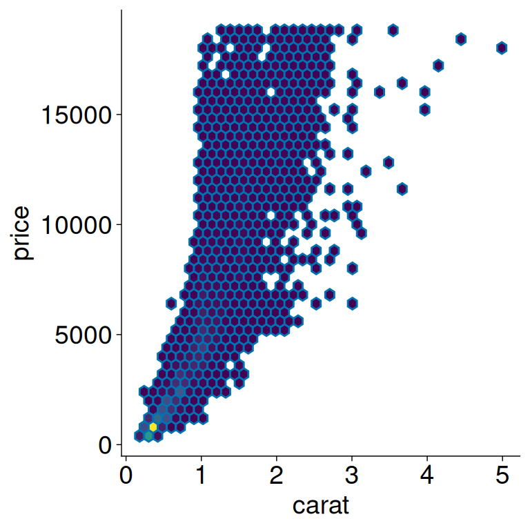